# Project: Investigate a Dataset - No-Show Appointments

- Introduction
  - Dataset Description
  - Data Dictionary
  - Questions for Analysis
- Data Wrangling
  - Load the Data
  - Data Field Inspection
  - Data Cleaning
- Exploratory Data Analysis
  - What appears to have the most impact on no-show appointments?
    - No-show_rate
    - days_between_rate
    - SMS_received_rate
    - No-show_rate by days_between_rate
    - No-show_rate by SMS_received_rate
  - Is there a relationship between the neighborhood in which the appointment  
    took place and whether the patient is enrolled in the Brasilian welfare program, Bolsa Familia?
    - Neighbourhood
    - Scholarship Proportion by Neighbourhood
- Conclusions
  - Limitations
- References

## Introduction

### Dataset Description

This analysis uses the kaggle dataset, [Medical Appointment No Shows](https://www.kaggle.com/joniarroba/noshowappointments). This dataset collects information from 100k medical appointments in Brazil and is focused on the question of whether or not patients show up for their appointment. A number of characteristics about the patient are included in each row.

### Data Dictionary

| Field | Description |
| --- | --- |
| PatientId | The unique identifier for each patient. |
| AppointmentID | The unique identifier for each appointment. |
| Gender | The gender of the patient. Possible choices are 'M' or 'F'. |
| ScheduledDay | The date on which the appointment was scheduled. Not to be confused with the date on which the appointment actually ocurrs. |
| AppointmentDay | The date on which the appointment takes place. Not to be confused with the date on which the appointment was scheduled, which can take place 0 or more days prior. |
| Age | The age in years of the patient on the day of their appointment. |
| Neighbourhood | The Neighborhood where the appointment took place. |
| Scholarship | True/False indicator of whether or not the patient is enrolled in the Brasilian welfare program, Bolsa Família. |
| Hipertension | True/False indicator of whether or not the patient had Hypertension. |
| Diabetes | True/False indicator of whether or not the patient had Diabetes. It is not specified whether the patient had type 1 or type 2 Diabetes. |
| Alcoholism | True/False indicator of whether or not the patient had Alcoholism. |
| Handcap | True/False indicator of whether or not the patient had a handicap. The type of handicap is not specified. |
| SMS_received | The number of text messages received to remind the patient about their appointment. |
| No-show | Yes/No indicator of whether or not the patient was a no-show to their appointment. Yes mean the patient did not show, No means they did show. |

### Questions for Analysis

1. What appears to have the most impact on no-show appointments?
   1. Days between Scheduled Date and Appointment Day?
   2. Number of SMS messages?
2. Is there a relationship between the neighborhood in which the appointment took place and whether the patient is enrolled in the Brasilian welfare program, Bolsa Familia?

```python
import matplotlib.pyplot as plt
import numpy as np
import pandas as pd
import scipy.stats as stats
import seaborn as sns

%matplotlib inline
```

## Data Wrangling

### Load the Data

Load the data from the downloaded .csv file into a pandas dataframe, parsing the dates for ScheduledDay and AppointmentDay.  
View the first fiew rows as well as the descriptive statistics of the data.

```python
df = pd.read_csv('./Database_No_show_appointments/noshowappointments-kagglev2-may-2016.csv',
                 parse_dates=['ScheduledDay', 'AppointmentDay'])
df.head()
```

|  | PatientId | AppointmentID | Gender | ScheduledDay | AppointmentDay | Age | Neighbourhood | Scholarship | Hipertension | Diabetes | Alcoholism | Handcap | SMS_received | No-show |
| --- | --- | --- | --- | --- | --- | --- | --- | --- | --- | --- | --- | --- | --- | --- |
| 0 | 2.987250e+13 | 5642903 | F | 2016-04-29 18:38:08+00:00 | 2016-04-29 00:00:00+00:00 | 62 | JARDIM DA PENHA | 0 | 1 | 0 | 0 | 0 | 0 | No |
| 1 | 5.589978e+14 | 5642503 | M | 2016-04-29 16:08:27+00:00 | 2016-04-29 00:00:00+00:00 | 56 | JARDIM DA PENHA | 0 | 0 | 0 | 0 | 0 | 0 | No |
| 2 | 4.262962e+12 | 5642549 | F | 2016-04-29 16:19:04+00:00 | 2016-04-29 00:00:00+00:00 | 62 | MATA DA PRAIA | 0 | 0 | 0 | 0 | 0 | 0 | No |
| 3 | 8.679512e+11 | 5642828 | F | 2016-04-29 17:29:31+00:00 | 2016-04-29 00:00:00+00:00 | 8 | PONTAL DE CAMBURI | 0 | 0 | 0 | 0 | 0 | 0 | No |
| 4 | 8.841186e+12 | 5642494 | F | 2016-04-29 16:07:23+00:00 | 2016-04-29 00:00:00+00:00 | 56 | JARDIM DA PENHA | 0 | 1 | 1 | 0 | 0 | 0 | No |

```python
df.describe()
```

|  | PatientId | AppointmentID | Age | Scholarship | Hipertension | Diabetes | Alcoholism | Handcap | SMS_received |
| --- | --- | --- | --- | --- | --- | --- | --- | --- | --- |
| count | 1.105270e+05 | 1.105270e+05 | 110527.000000 | 110527.000000 | 110527.000000 | 110527.000000 | 110527.000000 | 110527.000000 | 110527.000000 |
| mean | 1.474963e+14 | 5.675305e+06 | 37.088874 | 0.098266 | 0.197246 | 0.071865 | 0.030400 | 0.022248 | 0.321026 |
| std | 2.560949e+14 | 7.129575e+04 | 23.110205 | 0.297675 | 0.397921 | 0.258265 | 0.171686 | 0.161543 | 0.466873 |
| min | 3.921784e+04 | 5.030230e+06 | -1.000000 | 0.000000 | 0.000000 | 0.000000 | 0.000000 | 0.000000 | 0.000000 |
| 25% | 4.172614e+12 | 5.640286e+06 | 18.000000 | 0.000000 | 0.000000 | 0.000000 | 0.000000 | 0.000000 | 0.000000 |
| 50% | 3.173184e+13 | 5.680573e+06 | 37.000000 | 0.000000 | 0.000000 | 0.000000 | 0.000000 | 0.000000 | 0.000000 |
| 75% | 9.439172e+13 | 5.725524e+06 | 55.000000 | 0.000000 | 0.000000 | 0.000000 | 0.000000 | 0.000000 | 1.000000 |
| max | 9.999816e+14 | 5.790484e+06 | 115.000000 | 1.000000 | 1.000000 | 1.000000 | 1.000000 | 4.000000 | 1.000000 |

### Data Field Inspection

From the initial look at this data, there are several issues which will need to be addressed prior to analysis.

1. The PatientId and AppointmentID fields are displaying in scientific notation. Because these are solely meant for identification, they should not be numeric.
2. The Age column has a minimum value of -1. It is not possible to have negative ages. This will require further inspection.
3. The data types for Scholarship, Hipertension, Diabetes, Alcoholism, and Handcap should be boolean fields, not numeric.
4. The Handcap column should be True/False or 1/0, but it has a max of 4. However, SMS_received should be a count of text messages, but has a max of 1 and min of 0. It appears these two columns have been switched in the dataset.
5. No-show should, ideally, be a boolean field to match the others. Requires further inspection.

Before moving on to the cleaning phase, there are a couple of fields which require additional inspection.  
Let's start with the Age field.

```python
df[df['Age'] == -1]
```

|  | PatientId | AppointmentID | Gender | ScheduledDay | AppointmentDay | Age | Neighbourhood | Scholarship | Hipertension | Diabetes | Alcoholism | Handcap | SMS_received | No-show |
| --- | --- | --- | --- | --- | --- | --- | --- | --- | --- | --- | --- | --- | --- | --- |
| 99832 | 4.659432e+14 | 5775010 | F | 2016-06-06 08:58:13+00:00 | 2016-06-06 00:00:00+00:00 | -1 | ROMÃO | 0 | 0 | 0 | 0 | 0 | 0 | No |

There is no real indication as to why this patient's age is -1. Does this patient have other appointments in the data that could tell us what their age should be?

```python
PatientId = df.loc[99832, 'PatientId']
df[df['PatientId'] == PatientId]
```

|  | PatientId | AppointmentID | Gender | ScheduledDay | AppointmentDay | Age | Neighbourhood | Scholarship | Hipertension | Diabetes | Alcoholism | Handcap | SMS_received | No-show |
| --- | --- | --- | --- | --- | --- | --- | --- | --- | --- | --- | --- | --- | --- | --- |
| 99832 | 4.659432e+14 | 5775010 | F | 2016-06-06 08:58:13+00:00 | 2016-06-06 00:00:00+00:00 | -1 | ROMÃO | 0 | 0 | 0 | 0 | 0 | 0 | No |

This patient does not appear to have any other appointments in the dataset to base their age off of. Due to this, we will set the field to 0 for this patient during the cleaning phase.

Now we need to inspect the Handcap and SMS_received fields. Remember, the Handcap field should be True/False or 1/0 and the SMS_received field should be a count of text messages.

```python
print('Handcap:', df['Handcap'].unique())
print('SMS_received:', df['SMS_received'].unique())
```

```
Handcap: [0 1 2 3 4]
SMS_received: [0 1]
```

The fields do appear to have been switched. This will be addressed during the cleaning phase.

### Data Cleaning

For reference, these are the decisions we made during the Data Investigation phase:

1. The PatientId and AppointmentID fields are displaying in scientific notation. Because these are solely meant for identification, they should not be numeric.
2. The Age column has a minimum value of -1. It is not possible to have negative ages. This should be 0.
3. The data types for Scholarship, Hipertension, Diabetes, Alcoholism, and Handcap should be boolean fields, not numeric.
4. The Handcap column should be True/False or 1/0, but it has a max of 4. However, SMS_received should be a count of text messages, but has a max of 1 and min of 0. It appears these two columns have been switched in the dataset.
5. No-show should, ideally, be a boolean field to match the others.

1, let's change the data types of the ID columns to category. This prevents them from being summarized. To do this, we must first change the PatientId field to an integer to prevent it from displaying scientific notation. We'll also set the Gender and Neighborhood as a category while were here.

```python
# Creating a new copy of the dataset for cleaning
df_clean = df.copy(deep=True)

# change the types
df_clean['PatientId'] = df_clean['PatientId'].astype('int64').astype('category')
df_clean[['AppointmentID', 'Gender', 'Neighbourhood']] = \
    df_clean[['AppointmentID', 'Gender', 'Neighbourhood']].astype('category')

# check the work
print(df_clean[['PatientId', 'AppointmentID', 'Gender', 'Neighbourhood']].dtypes)
df_clean[['PatientId', 'AppointmentID', 'Gender', 'Neighbourhood']].describe()
```

```
PatientId        category
AppointmentID    category
Gender           category
Neighbourhood    category
dtype: object
```

|  | PatientId | AppointmentID | Gender | Neighbourhood |
| --- | --- | --- | --- | --- |
| count | 110527 | 110527 | 110527 | 110527 |
| unique | 62299 | 110527 | 2 | 81 |
| top | 822145925426128 | 5030230 | F | JARDIM CAMBURI |
| freq | 88 | 1 | 71840 | 7717 |

88 visits!! That seems really high! Let's take a look at that patient.

```python
patient_88 = df_clean[df_clean['PatientId'] == 822145925426128]. \
    groupby('AppointmentDay', as_index=False, sort=True)['AppointmentID'].count()
patient_88.head()
```

|  | AppointmentDay | AppointmentID |
| --- | --- | --- |
| 0 | 2016-04-29 00:00:00+00:00 | 3 |
| 1 | 2016-05-02 00:00:00+00:00 | 3 |
| 2 | 2016-05-03 00:00:00+00:00 | 1 |
| 3 | 2016-05-04 00:00:00+00:00 | 5 |
| 4 | 2016-05-05 00:00:00+00:00 | 1 |

This high count seems to be due to the patient having multiple appointments in a given day.

Is this an edge case or do other patients have the same pattern? To determine this, we first need to count the number of appointments per day per patient. Then we can filter the list of patients to those who have more than one appointment on any given day.

```python
multi_appts_index = df_clean.groupby(['PatientId', 'AppointmentDay'])['AppointmentID'].count() > 1
```

```python
multi_appts = df_clean.groupby(['PatientId', 'AppointmentDay'])['AppointmentID'].count()[multi_appts_index]
multi_appts
```

```
PatientId        AppointmentDay
178168233        2016-05-02 00:00:00+00:00    2
269919126        2016-05-20 00:00:00+00:00    2
522584745        2016-05-16 00:00:00+00:00    2
555199469        2016-05-30 00:00:00+00:00    2
724118924        2016-05-10 00:00:00+00:00    4
                                             ..
998882118364464  2016-05-03 00:00:00+00:00    2
999277798221655  2016-05-05 00:00:00+00:00    2
999336432895567  2016-05-05 00:00:00+00:00    2
999627467948438  2016-05-16 00:00:00+00:00    2
999931985292928  2016-05-17 00:00:00+00:00    2
Name: AppointmentID, Length: 7481, dtype: int64
```

There are 7481 ocurrences of a patient having more than one visit in a single day. This leads me to believe things like lab draws, radiology, and other ancillary testing are scheduled in separate appointments. It does, however introduce a new question: Is this data for inpatient or outpatient settings? Or is it for both? Unfortunately, this is not information which was provided with the dataset. For now, we will have to assume it includes both.

2, replace the negative age we found earlier with 0

```python
df_clean['Age'] = df_clean['Age'].replace(-1, 0)
df_clean['Age'].describe()
```

```
count    110527.000000
mean         37.088883
std          23.110190
min           0.000000
25%          18.000000
50%          37.000000
75%          55.000000
max         115.000000
Name: Age, dtype: float64
```

3, the data type of the Scholarship, Hipertension, Diabetes, Alcoholism, and Handcap fields. Becuase of the Handcap/SMS_received switch, that column will be handeled in the next step

```python
df_clean.loc[:, ['Scholarship', 'Hipertension', 'Diabetes', 'Alcoholism']] = \
    df_clean.loc[:, ['Scholarship', 'Hipertension', 'Diabetes', 'Alcoholism']].astype(bool)
df_clean[['Scholarship', 'Hipertension', 'Diabetes', 'Alcoholism']].dtypes
```

```
Scholarship     bool
Hipertension    bool
Diabetes        bool
Alcoholism      bool
dtype: object
```

4, the Handcap and SMS_received fields. Recall that they appear to be switched. Handcap should be True/False or 1/0 and SMS_received should be a count. So, we will first switch the columns, then change Handcap to a bool field.

```python
df_clean.loc[:, ['Handcap', 'SMS_received']] = df_clean[['SMS_received', 'Handcap']]
df_clean.loc[:, 'Handcap'] = df_clean['Handcap'].astype(bool)
print(df_clean[['Handcap', 'SMS_received']].dtypes)
df_clean[['Handcap', 'SMS_received']].head()
```

```
Handcap          bool
SMS_received    int64
dtype: object
```

|  | Handcap | SMS_received |
| --- | --- | --- |
| 0 | False | 0 |
| 1 | False | 0 |
| 2 | False | 0 |
| 3 | False | 0 |
| 4 | False | 0 |

5, Switch the No-show field to True/False

```python
df_clean.loc[:, 'No-show'] = df_clean['No-show'].replace('Yes', True).replace('No', False).astype(bool)
df_clean['No-show'].head()
```

```
0    False
1    False
2    False
3    False
4    False
Name: No-show, dtype: bool
```

At this point, we have addressed all of the identified issues with the dataset. However, there is one more field we will need. We will need the number of days between the date the appointment was scheduled and the date of the appointment. Let's add that now.

```python
df_clean.loc[:, 'days_between'] = (df_clean['AppointmentDay'].dt.date - df_clean['ScheduledDay'].dt.date).dt.days
df_clean['days_between'].describe()
```

```
count    110527.000000
mean         10.183702
std          15.254996
min          -6.000000
25%           0.000000
50%           4.000000
75%          15.000000
max         179.000000
Name: days_between, dtype: float64
```

Looking at the maximum value, 179 does seem high. But, when you think about it, some patients have appointments every 6 months an schedule each subsequent appointment before leaving the office. For this reason, we will consider 179 a valid number of days. However, it is not possible to scheduld an appointment after it has occurred. Let's take a look at those to see if we can figure out what happened.

```python
df_clean[df_clean['days_between'] < 0.0]
```

|  | PatientId | AppointmentID | Gender | ScheduledDay | AppointmentDay | Age | Neighbourhood | Scholarship | Hipertension | Diabetes | Alcoholism | Handcap | SMS_received | No-show | days_between |
| --- | --- | --- | --- | --- | --- | --- | --- | --- | --- | --- | --- | --- | --- | --- | --- |
| 27033 | 7839272661752 | 5679978 | M | 2016-05-10 10:51:53+00:00 | 2016-05-09 00:00:00+00:00 | 38 | RESISTÊNCIA | False | False | False | False | True | 0 | True | -1 |
| 55226 | 7896293967868 | 5715660 | F | 2016-05-18 14:50:41+00:00 | 2016-05-17 00:00:00+00:00 | 19 | SANTO ANTÔNIO | False | False | False | False | True | 0 | True | -1 |
| 64175 | 24252258389979 | 5664962 | F | 2016-05-05 13:43:58+00:00 | 2016-05-04 00:00:00+00:00 | 22 | CONSOLAÇÃO | False | False | False | False | False | 0 | True | -1 |
| 71533 | 998231581612122 | 5686628 | F | 2016-05-11 13:49:20+00:00 | 2016-05-05 00:00:00+00:00 | 81 | SANTO ANTÔNIO | False | False | False | False | False | 0 | True | -6 |
| 72362 | 3787481966821 | 5655637 | M | 2016-05-04 06:50:57+00:00 | 2016-05-03 00:00:00+00:00 | 7 | TABUAZEIRO | False | False | False | False | False | 0 | True | -1 |

There does not seem to be any legitimate reason by looking at the affected records. We will set these to 0 since that is the lowest possible value.

```python
df_clean.loc[df_clean['days_between'] < 0, 'days_between'] = 0
df_clean['days_between'].describe()
```

```
count    110527.000000
mean         10.183792
std          15.254924
min           0.000000
25%           0.000000
50%           4.000000
75%          15.000000
max         179.000000
Name: days_between, dtype: float64
```

Now, to take one more peak at the structure to make sure we have everything in order...

```python
df_clean.info()
```

```
<class 'pandas.core.frame.DataFrame'>
RangeIndex: 110527 entries, 0 to 110526
Data columns (total 15 columns):
 #   Column          Non-Null Count   Dtype
---  ------          --------------   -----
 0   PatientId       110527 non-null  category
 1   AppointmentID   110527 non-null  category
 2   Gender          110527 non-null  category
 3   ScheduledDay    110527 non-null  datetime64[ns, UTC]
 4   AppointmentDay  110527 non-null  datetime64[ns, UTC]
 5   Age             110527 non-null  int64
 6   Neighbourhood   110527 non-null  category
 7   Scholarship     110527 non-null  bool
 8   Hipertension    110527 non-null  bool
 9   Diabetes        110527 non-null  bool
 10  Alcoholism      110527 non-null  bool
 11  Handcap         110527 non-null  bool
 12  SMS_received    110527 non-null  int64
 13  No-show         110527 non-null  bool
 14  days_between    110527 non-null  int64
dtypes: bool(6), category(4), datetime64[ns, UTC](2), int64(3)
memory usage: 13.3 MB
```

## Exploratory Data Analysis

### What appears to have the most impact on no-show appointments?

1. Days between Scheduled Date and Appointment Day?
2. Number of SMS messages?

First we need to get the variables of interest, which are the PatientId, days_between, SMS_received, and No-show fields.

```python
df_noshow_expl = df_clean.loc[:, ['PatientId', 'days_between', 'SMS_received', 'No-show']]
```

Next, we will add a column of 1's to represent the appointment count per line. This will help with our aggregations later.

```python
df_noshow_expl['appt_count'] = 1
```

After that, we can group by the PatientId field and sum everything else to get a total per patient for each field.

> Note: Remember, we switched the Handcap and SMS_received fields earlier becuase their structures did not match their definitions on the Kaggle website. This makes SMS_received a numeric field, not a categorical or bivariate field as was identified in the raw data.

```python
df_noshow_expl = df_noshow_expl.groupby('PatientId').sum()
```

Lastly, we will divide each of the columns by the appointment count to get a per appointment rate for each patient. This will make more sense than the sum of each field per patient.

```python
df_noshow_expl.loc[:, 'days_between_rate'] = df_noshow_expl['days_between'].div(df_noshow_expl['appt_count'])
df_noshow_expl.loc[:, 'SMS_received_rate'] = df_noshow_expl['SMS_received'].div(df_noshow_expl['appt_count'])
df_noshow_expl.loc[:, 'No-show_rate'] = df_noshow_expl['No-show'].div(df_noshow_expl['appt_count'])
```

Now, let's take a peak to make sure the data looks as expected

```python
df_noshow_expl.head()
```

| PatientId | days_between | SMS_received | No-show | appt_count | days_between_rate | SMS_received_rate | No-show_rate |
| --- | --- | --- | --- | --- | --- | --- | --- |
| 39217 | 3 | 0 | 0 | 1 | 3.0 | 0.0 | 0.0 |
| 43741 | 0 | 0 | 0 | 1 | 0.0 | 0.0 | 0.0 |
| 93779 | 0 | 0 | 0 | 1 | 0.0 | 0.0 | 0.0 |
| 141724 | 3 | 0 | 0 | 1 | 3.0 | 0.0 | 0.0 |
| 537615 | 7 | 1 | 0 | 1 | 7.0 | 1.0 | 0.0 |

Looks good. And the descriptive stats...

```python
df_noshow_expl.describe()
```

|  | days_between | SMS_received | No-show | appt_count | days_between_rate | SMS_received_rate | No-show_rate |
| --- | --- | --- | --- | --- | --- | --- | --- |
| count | 62299.000000 | 62299.000000 | 62299.000000 | 62299.000000 | 62299.000000 | 62299.000000 | 62299.000000 |
| mean | 18.067449 | 0.569544 | 0.358256 | 1.774138 | 11.155471 | 0.330407 | 0.196430 |
| std | 24.513593 | 0.798240 | 0.689779 | 1.770324 | 15.058079 | 0.419886 | 0.351419 |
| min | 0.000000 | 0.000000 | 0.000000 | 1.000000 | 0.000000 | 0.000000 | 0.000000 |
| 25% | 0.000000 | 0.000000 | 0.000000 | 1.000000 | 0.000000 | 0.000000 | 0.000000 |
| 50% | 8.000000 | 0.000000 | 0.000000 | 1.000000 | 5.500000 | 0.000000 | 0.000000 |
| 75% | 28.000000 | 1.000000 | 1.000000 | 2.000000 | 16.500000 | 0.666667 | 0.333333 |
| max | 428.000000 | 16.000000 | 18.000000 | 88.000000 | 179.000000 | 1.000000 | 1.000000 |

#### No-show_rate

First we'll take a more detailed look at the no-show field.

```python
df_noshow_expl['No-show_rate'].describe()
```

```
count    62299.000000
mean         0.196430
std          0.351419
min          0.000000
25%          0.000000
50%          0.000000
75%          0.333333
max          1.000000
Name: No-show_rate, dtype: float64
```

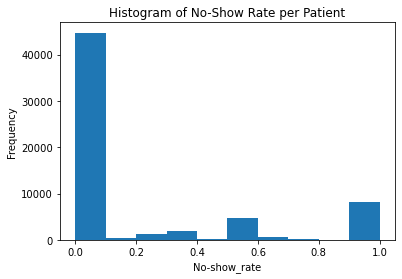

```python
fig, ax = plt.subplots()
ax.hist(df_noshow_expl['No-show_rate'])
ax.set_title('Histogram of No-Show Rate per Patient')
ax.set_xlabel('No-show_rate')
ax.set_ylabel('Frequency')
print()
```

The data looks as we expect. Because the fields were averaged over the appointment count per patient, the result can never be more than one. And, of course, we would expect that most patients attend the appointments they schedule, making the data skewed in the positive direction.

#### days_between_rate

Next, we will take a closer look at days_between.

```python
df_noshow_expl['days_between_rate'].describe()
```

```
count    62299.000000
mean        11.155471
std         15.058079
min          0.000000
25%          0.000000
50%          5.500000
75%         16.500000
max        179.000000
Name: days_between_rate, dtype: float64
```

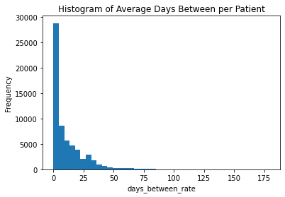

```python
fig, ax = plt.subplots()
ax.hist(df_noshow_expl['days_between_rate'], bins=40)
ax.set_title('Histogram of Average Days Between per Patient')
ax.set_xlabel('days_between_rate')
ax.set_ylabel('Frequency')
print()
```

Above is a histogram of the average days between scheduling and appointment and attending (or missing) an appointment per patient. We can see that the data is heavily skewed in the positive direction. This means there are most likely outliers in the dataset. Let's identify them.

First, we must get the Interquartile Range (IQR). Using the values for quartiles 1 and 3 in the descriptive stats above (0 and 16.5, respectively), we calculate IQR as 16.5 days. We can then find the outlier threshold as Q3 + 1.5(IQR). After that, we can identify and exclude them from the data.

```python
iqr = 16.5
q3 = 16.5
upper_limit = q3 + (1.5 * iqr)
print('Upper Limit for Outliers:', upper_limit)
```

```
Upper Limit for Outliers: 41.25
```

Now that we've identified the cutoff for outliers, we'll exclude them and take another look at the descriptive stats.

```python
df_noshow_expl = df_noshow_expl.loc[df_noshow_expl['days_between_rate'] <= upper_limit, :]
df_noshow_expl['days_between_rate'].describe()
```

```
count    59591.000000
mean         8.946319
std         10.317793
min          0.000000
25%          0.000000
50%          5.000000
75%         14.500000
max         41.000000
Name: days_between_rate, dtype: float64
```

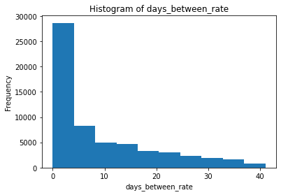

```python
fig, ax = plt.subplots()
ax.hist(df_noshow_expl['days_between_rate'])
ax.set_title('Histogram of days_between_rate')
ax.set_xlabel('days_between_rate')
ax.set_ylabel('Frequency')
print()
```

#### SMS_received_rate

The last field we need to take a closer look at is SMS_received_rate

```python
df_noshow_expl['SMS_received_rate'].describe()
```

```
count    59591.000000
mean         0.316273
std          0.412696
min          0.000000
25%          0.000000
50%          0.000000
75%          0.666667
max          1.000000
Name: SMS_received_rate, dtype: float64
```

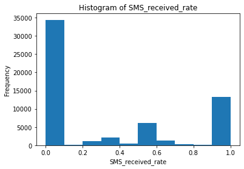

```python
fig, ax = plt.subplots()
ax.hist(df_noshow_expl['SMS_received_rate'])
ax.set_title('Histogram of SMS_received_rate')
ax.set_xlabel('SMS_received_rate')
ax.set_ylabel('Frequency')
print()
```

#### No-show_rate by days_between_rate

Now that we know the general structure of the fields we are analyzing, we can compare them. To answer our question, first we need to determine what impact the amount of time between scheduled_date and appointment_date has on a patient's No-show rate. Below is a scatter plot displaying a first look at this. Here are the steps that will be taken to create the visual:

1. Create functions to calculate the slope, y-intercept, and line of best fit.
2. Perform calculations needed for the chart.
3. Plot the scatter chart.

```python
## Functions to calculate the slope and intercept, as well as the line of best fit
## y = m(x) + b

def slope_intercept(x, y):
    m = pd.Series(dtype='float64')
    b = pd.Series(dtype='float64')

    m = np.round(((x.mean() * y.mean()) - (x * y).mean()) / ((x.mean() * x.mean()) - (x * x).mean()), 2)
    b = np.round((y.mean() - (m * x.mean())).round(2), 2)

    return m, b

def line_best_fit(x, y):
    m, b = slope_intercept(x, y)
    line = (m * x) + b
    return line
```

```python
## Set x, and y for the plot
x = df_noshow_expl['days_between_rate']
y = df_noshow_expl['No-show_rate']

## Set the slope, intercept, and line of best fit for the plot
m, b = slope_intercept(x, y)
line = line_best_fit(x, y)

## Set color, size, and transparency for the plot
s = df_noshow_expl['appt_count'] * 50
c = df_noshow_expl['appt_count']
marker = '.'
alpha = 0.50
```

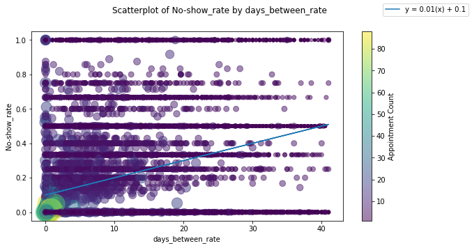

```python
## Set up the figure and subplot
fig, ax = plt.subplots(figsize=(10, 5))
fig.suptitle('Scatterplot of No-show_rate by days_between_rate')

## Set up the plot
ax.scatter(x, y, s, c, alpha=alpha, marker=marker)
ax.plot(x, line, label = 'y = ' + str(m) + '(x) + ' + str(b))
ax.set_xlabel('days_between_rate')
ax.set_ylabel('No-show_rate')
fig.legend()

## Set up legend and color bar
mappable = ax.collections[0]
fig.colorbar(mappable, ax=ax, location='right', label='Appointment Count')
print() # Prevents output from colorbar
```

Now, let's dig in to what we have here. The dependent variable, No-show_rate, is displayed on the y-axis; and the independent variable, days_between_rate, is displayed on the x-axis. Each point represents a single patient. Both the color and size of each point represents the number of appointments each patient had. The blue line is the calculated line of best fit, with the associated formula displayed in the upper right-hand corner.

As we would expect, the patients with a high appointment count did not have any no-shows. From the line of best fit and linear formula, it appears there is a weak, positive correlation between the two variables. In the next section, a one-tailed t-test will be performed to determine if the difference between no-shows in patients who average zero days between scheduling an appointment and the appointment date, and those who average more than zero, is significant.

First, the data needs to be split into two groups: those whose days_between = 0; and those whose days_between > 0.

```python
df_zero_days_between = df_noshow_expl[df_noshow_expl['days_between_rate'] == 0]
df_any_days_between = df_noshow_expl[df_noshow_expl['days_between_rate'] > 0]
```

Once the data is split, the basic statistics are calculated including the mean, standard deviation or standard error where appropriate.

```python
## Calculate n, mean, variance, and standard deviation for each group
n_zero = df_zero_days_between['No-show_rate'].count()
mean_zero = df_zero_days_between['No-show_rate'].mean()
var_zero = df_zero_days_between['No-show_rate'].var()
std_zero = df_zero_days_between['No-show_rate'].std()

n_any = df_any_days_between['No-show_rate'].count()
mean_any = df_any_days_between['No-show_rate'].mean()
var_any = df_any_days_between['No-show_rate'].var()
std_any = df_any_days_between['No-show_rate'].std()

## Calculate mean difference
mean_noshow_diff = mean_any - mean_zero

## Calculate the standard error of the difference
se_noshow_diff = np.sqrt((var_any / n_any) + (var_zero / n_zero))

print('Zero Days Between: M={}, var={}, S={}'.format(np.round(mean_zero,2), np.round(var_zero, 2), np.round(std_zero, 2)))
print('Any Days Between: M={}, var={}, S={}'.format(np.round(mean_any, 2), np.round(var_any, 2), np.round(std_any, 2)))
print('Difference: M={}, var={}, SE={}'.format(
    np.round(mean_noshow_diff, 2), np.round(var_any, 2), np.round(se_noshow_diff, 2)))
```

```
Zero Days Between: M=0.03, var=0.03, S=0.16
Any Days Between: M=0.25, var=0.14, S=0.38
Difference: M=0.22, var=0.14, SE=0.0
```

Now we run a one-tailed, independent, two-sample t-test to determine if the difference in means is statistically significant. Because the variance for the two samples are not equal, the test ran will actually be Welch’s t-test, indicated by `equal_var=False` below. From the initial graph, we know the mean will increase, which is why the test will be one-tailed in the positive direction, indicated by `alternative='greater'`, below. An alpha of .05 will be used to determine significance.

```python
t_stat_noshow_diff, p_val_noshow_diff = stats.ttest_ind(
    df_any_days_between['No-show_rate'], df_zero_days_between['No-show_rate'], equal_var=False, alternative='greater'
)
print('t-statistic =', np.round(t_stat_noshow_diff,2 ), ', p-value =', p_val_noshow_diff)
```

```
t-statistic = 100.2 , p-value = 0.0
```

The t-statistic is a whopping 100.2, with a p-value of 0.0, meaning there is virtually no chance that the difference could have ocurred by chance. The next step is to calculate the 95% confidence interval for the difference in means, which was 0.22.

```python
confidence_level = 0.95
degrees_freedom = (n_zero - 1) + (n_any - 1)
sample_mean = mean_noshow_diff
sample_standard_error = se_noshow_diff

confidence_interval = stats.t.interval(confidence_level, degrees_freedom, sample_mean, sample_standard_error)
confidence_interval
```

```
(0.21650277227745932, 0.22514145398166638)
```

So what does this mean? This means that we can say it appears adding any amount of time between the date an appointment is scheduled and the date of the appointment will increase that patient's No-show rate by 0.22, 95% CI [0.217, 0.225]. This result was found to be statistically significant, t(59589)=100.2, p=.0.

#### No-show_rate by SMS_received_rate

We're going to do pretty much the same thing we just did, but with the SMS_received_rate field instead of the days_between_rate field. To answer our question, next we need to determine what impact the rate of text messages received has on a patient's No-show rate. We'll start with a plot again, but this time it will only take two steps becuase the function has already been created.

1. Perform calculations needed for the chart.
2. Plot the scatter chart.

```python
## Set x, and y for the plot
x = df_noshow_expl['SMS_received_rate']
y = df_noshow_expl['No-show_rate']

## Set the slope, intercept, and line of best fit for the plot
m, b = slope_intercept(x, y)
line = line_best_fit(x, y)

## Set color, size, and transparency for the plot
s = df_noshow_expl['appt_count'] * 50
c = df_noshow_expl['appt_count']
marker = '.'
alpha = 0.50
```

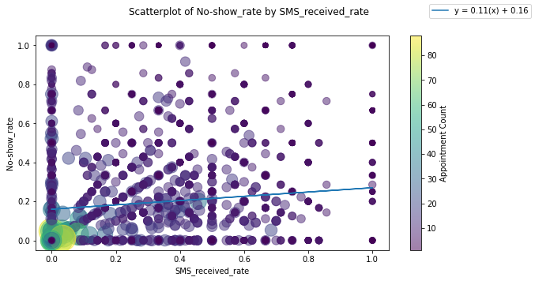

```python
## Set up the figure and subplot
fig, ax = plt.subplots(figsize=(10, 5))
fig.suptitle('Scatterplot of No-show_rate by SMS_received_rate')

## Set up the plot
ax.scatter(x, y, s, c, alpha=alpha, marker=marker)
ax.plot(x, line, label = 'y = ' + str(m) + '(x) + ' + str(b))
ax.set_xlabel('SMS_received_rate')
ax.set_ylabel('No-show_rate')
fig.legend()

## Set up legend and color bar
mappable = ax.collections[0]
fig.colorbar(mappable, ax=ax, location='right', label='Appointment Count')
print() # Prevents output from colorbar
```

From the line of best fit and linear formula, it appears there is again a weak, positive correlation between the two variables. Like was done last time, a one-tailed t-test will be performed to determine if the difference between no-shows in patients who average zero text message reminders, and those who average more than zero, is significant.

Again, the data needs to be split into two groups: those whose SMS_received_rate = 0; and those whose SMS_received_rate > 0.

```python
df_zero_SMS_received = df_noshow_expl[df_noshow_expl['SMS_received_rate'] == 0]
df_any_SMS_received = df_noshow_expl[df_noshow_expl['SMS_received_rate'] > 0]
```

Next, we calculate the descriptive stats mean, variance, standard deviation, and standard error where appropriate so that we can find the difference between them.

```python
## Calculate n, mean, variance, and standard deviation for each group
n_zero = df_zero_SMS_received['No-show_rate'].count()
mean_zero = df_zero_SMS_received['No-show_rate'].mean()
var_zero = df_zero_SMS_received['No-show_rate'].var()
std_zero = df_zero_SMS_received['No-show_rate'].std()

n_any = df_any_SMS_received['No-show_rate'].count()
mean_any = df_any_SMS_received['No-show_rate'].mean()
var_any = df_any_SMS_received['No-show_rate'].var()
std_any = df_any_SMS_received['No-show_rate'].std()

## Calculate mean difference
mean_noshow_diff = mean_any - mean_zero

## Calculate the standard error of the difference
se_noshow_diff = np.sqrt((var_any / n_any) + (var_zero / n_zero))

print('Zero Days Between: M={}, var={}, S={}'.format(np.round(mean_zero,2), np.round(var_zero, 2), np.round(std_zero, 2)))
print('Any Days Between: M={}, var={}, S={}'.format(np.round(mean_any, 2), np.round(var_any, 2), np.round(std_any, 2)))
print('Difference: M={}, var={}, SE={}'.format(
    np.round(mean_noshow_diff, 2), np.round(var_any, 2), np.round(se_noshow_diff, 3)))
```

```
Zero Days Between: M=0.15, var=0.11, S=0.33
Any Days Between: M=0.25, var=0.13, S=0.36
Difference: M=0.09, var=0.13, SE=0.003
```

We will, again, run a one-tailed, independent, two-sample t-test to determine if the difference in means is statistically significant. The variances for the two samples are a lot closer than for days_between_rate, however are not equal. So, the test ran will still be Welch’s t-test, indicated by `equal_var=False` below. Just like before, when looking at the initial graph, we know the mean will increase, which is why the test will be one-tailed in the positive direction, indicated by `alternative='greater'`, below. Again, an alpha of .05 will be used to determine significance.

```python
t_stat_noshow_diff, p_val_noshow_diff = stats.ttest_ind(
    df_any_SMS_received['No-show_rate'], df_zero_SMS_received['No-show_rate'], equal_var=False, alternative='greater'
)
print('t-statistic =', np.round(t_stat_noshow_diff, 2), ', p-value =', p_val_noshow_diff)
```

```
t-statistic = 32.22 , p-value = 7.551463410859679e-226
```

The level of significance for this difference is quite a bit lower than the previous difference. Recall that days_between's t-statistic was over 100 with a p-value of 0. While 32.22 is not nearly as high as 100, the p-value still indicates that the finding is statistically significant with a value that is definitely less than .05. Let's finish off with the 95% confidence intervals as we did before.

```python
confidence_level = 0.95
degrees_freedom = (n_zero - 1) + (n_any - 1)
sample_mean = mean_noshow_diff
sample_standard_error = se_noshow_diff

confidence_interval = stats.t.interval(confidence_level, degrees_freedom, sample_mean, sample_standard_error)
confidence_interval
```

```
(0.0870634068875629, 0.0983412944183786)
```

From this information, we can say that it appears that receiving SMS messages increases patients' no-show rates (M=0.09, SE=0.003) with 95% CI [0.087, 0.098]. Wait, that doesn't make sense! If these findings are correct, they suggest that receiving a text message could decrease your chance of showing up for an appointment. It appears there may be a lurking variable somewhere. One possibility is that people who sign up to receive text reminders for their appointments are more proned to forgetting them in the first place. This is just spectulation, of course, and the results can't actually imply causation. But, it does raise some interesting questions which would be great to test with a broader dataset.

Now, for the original question, which of the two variables has a greater impact on No-show? The winner is... the number of days, on average, between the date on which an appointment was scheduled and the date of the appointment. In less confusing words, the gap between scheduling and attending an appointment. We know this because the test with days_between_rate had a mean difference of 0.22 in the no-show_rate but the test with SMS_received_rate only had a mean difference of 0.09 in no-show_rate. Realistically, we can't say that either caused this to happen, but there was a greater change observed with the days_between_rate variable.

### Is there a relationship between the neighborhood in which the appointment took place and whether the patient is enrolled in the Brasilian welfare program, Bolsa Familia?

As we did with the previous question, the first step is gathering the variables. This time, we will only need Neighborhood and Scholarship. I'll also add a column of 1's to aid in counting the appointments like before.

```python
df_neighbourhood_scholarship = df_clean.loc[:, ['Neighbourhood', 'Scholarship']]
df_neighbourhood_scholarship['appt_count'] = 1
```

#### Neighbourhood

Before doing anything to the data, we'll take a look at the Neighbourhood field, just to get a sense of the distribution.

```python
df_neighbourhood_scholarship['Neighbourhood'].describe()
```

```
count             110527
unique                81
top       JARDIM CAMBURI
freq                7717
Name: Neighbourhood, dtype: object
```

Because Neighbourhood is a categorical field, a histogram is not really the ideal way to visualize the data. Instead, a bar chart will be use. To do this, the data must first be grouped, counted, and sorted.

```python
appt_count_by_neighbourhood = df_neighbourhood_scholarship.loc[:, ['Neighbourhood', 'appt_count']] \
    .groupby('Neighbourhood', as_index=False).count() \
    .sort_values(by='appt_count')
```

Now it can be visualized.

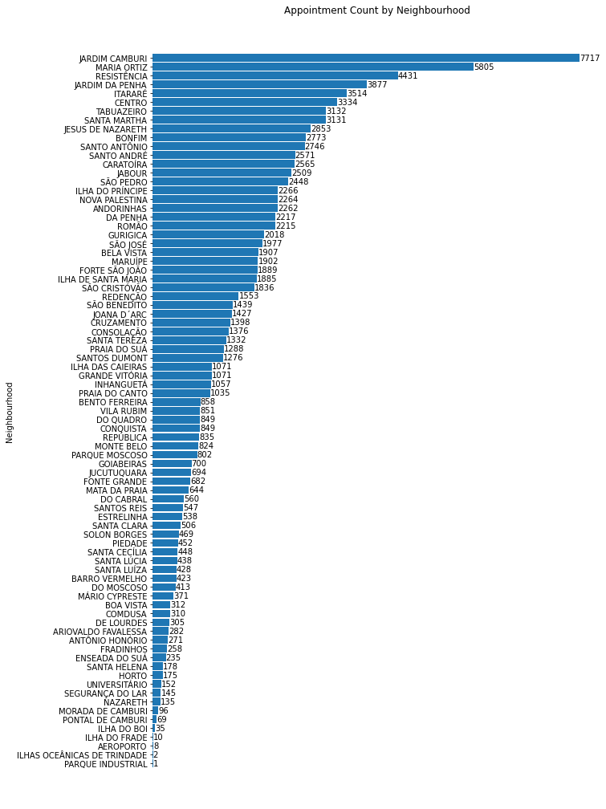

```python
fig, ax = plt.subplots(figsize=(10, 18))
bar = ax.barh(appt_count_by_neighbourhood['Neighbourhood'], appt_count_by_neighbourhood['appt_count'], height=0.9)
ax.bar_label(bar, appt_count_by_neighbourhood['appt_count'], fmt='%d')
ax.set_title('Appointment Count by Neighbourhood')
ax.set_ylabel('Neighbourhood')
ax.xaxis.set_visible(False)
ax.set_frame_on(False)
print()
```

There are 81 unique neighbourhoods with a minimum count of 1 appointment in Parque Industrial and a maximumn count of 7,717 appointments Jardim Camburi.

#### Scholarship proportion by Neighborhood

Now that we know what the Neighbourhood field reall looks like, we can calculate the proportion of appointments where patients were enrolled in the program for each neighborhood. This comparison will be more fair due to the wide range of appointment counts. The first step is to group the data, again by neighbourhood, but this time summing the fields to get a count of appointments where patients were enrolled in the program and an overall count of appointments.

```python
df_neighbourhood_scholarship = df_neighbourhood_scholarship.groupby('Neighbourhood', as_index=False).sum()
```

Now the scholarship proportion can be calculated for each neighborhood by dividing the scholarship count by the appointment count.

```python
df_neighbourhood_scholarship['scholarship_proportion'] = \
    (df_neighbourhood_scholarship['Scholarship'] / df_neighbourhood_scholarship['appt_count'])
```

Now that the proportion of scholarship appointments has been calculated, let's plot it. The figure will display two bar charts, both like the previous one, sorted by appointment count. One will display the raw counts of appointments and appointments with scholarship, and the other will display the proportions as a 100% stacked bar. Hopefully this will give us some insight into whether scholarship is proportionate across the board, or if there are some neighborhoods with more scholarship patients.

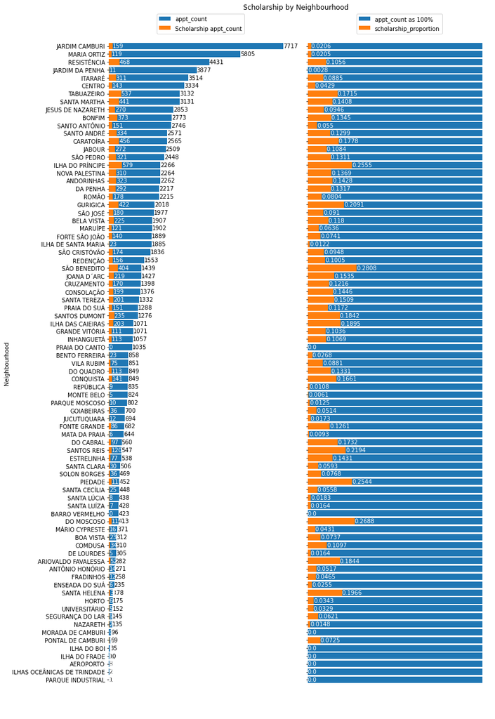

```python
## Sort the data by appt_count
df_neighbourhood_scholarship.sort_values(by='appt_count', inplace=True)

## Set up figure
fig, (ax1, ax2) = plt.subplots(1, 2, figsize=(10, 18), sharey='row')
fig.suptitle('Scholarship by Neighbourhood')
fig.tight_layout()

## Set up the first plot
bar1 = ax1.barh(df_neighbourhood_scholarship['Neighbourhood'],
                df_neighbourhood_scholarship['appt_count'],
                label='appt_count')
ax1.bar_label(bar1, df_neighbourhood_scholarship['appt_count'])
bar2 = ax1.barh(df_neighbourhood_scholarship['Neighbourhood'],
                df_neighbourhood_scholarship['Scholarship'],
                label='Scholarship appt_count')
ax1.bar_label(bar2, df_neighbourhood_scholarship['Scholarship'].round(4), color='white')
ax1.set_frame_on(False)
ax1.xaxis.set_visible(False)
ax1.set_ylabel('Neighbourhood')
ax1.legend(loc='upper center')

## Set up the second plot
bar3 = ax2.barh(df_neighbourhood_scholarship['Neighbourhood'],
                [1.0 for i in df_neighbourhood_scholarship['Neighbourhood']],
                label='appt_count as 100%')
bar4 = ax2.barh(df_neighbourhood_scholarship['Neighbourhood'],
                df_neighbourhood_scholarship['scholarship_proportion'],
                label='scholarship_proportion')
ax2.bar_label(bar4, df_neighbourhood_scholarship['scholarship_proportion'].round(4), color='white')
ax2.set_frame_on(False)
ax2.xaxis.set_visible(False)
ax2.legend(loc='upper center')
print()
```

Looking at this set of charts, it is pretty obvious that the scholarship proportion is not equal across the population, nor does it appear to be higher in neighbourhoods with higer appointment counts. Of course this is only anectodal based solely on the visual. Let's calculate whether the highest proportion scholarship is significantly higher than the mean proportion. To do this, the t-statistic must be calculated for the neighbourhood with the highest proportion of scholarship.

First, the basic descriptive statistics need to be calculated, including the maximum, mean, count, and standard deviation.

```python
## Calculate the max, n, mean, standard error, t-statistic, and p-value
max_neighbourhood = df_neighbourhood_scholarship['Neighbourhood'].iloc[
    df_neighbourhood_scholarship['scholarship_proportion'].argmax()
]
prop_max = df_neighbourhood_scholarship['scholarship_proportion'].max()
prop_n = df_neighbourhood_scholarship['scholarship_proportion'].count()
prop_mean = df_neighbourhood_scholarship['scholarship_proportion'].mean()
prop_std = df_neighbourhood_scholarship['scholarship_proportion'].std()

print('Scholarship Proportion Stats:')
print('\tMaximum:', max_neighbourhood, 'with', prop_max.round(2))
print('\tSample n:', prop_n)
print('\tMean:', prop_mean.round(2))
print('\tStandard Deviation:', prop_std.round(2))
```

```
Scholarship Proportion Stats:
	Maximum: SÃO BENEDITO with 0.28
	Sample n: 81
	Mean: 0.09
	Standard Deviation: 0.07
```

Here, we see that SÃO BENEDITO has the maximum proportion of scholarship appointments at 0.28. We can also see that it is being compared to 80 other neighbourhoods, with a mean proportion of 0.09 with a standard deviation of 0.07. Using this information, the standard error of the sampling distribution can be determined.

```python
prop_se = prop_std / np.sqrt(prop_n)
print('Standard Error:', prop_se.round(2))
```

```
Standard Error: 0.01
```

Then, using the proportion maximum, mean, and standard error, the t-statistic and p-value can be calculated for a one-tailed single sample positive directional t-test. The test is being ran directionally becuase we already know that the maximum value is larger than the mean. It would not make sense to test this in the negative direction. For this test, an alpha of 0.05 will be used to determine significance.

```python
prop_max_t = (prop_max - prop_mean) / prop_se
prop_max_p = stats.t.sf(abs(prop_max_t), df=(prop_n-1))
print('\tMaximum t-statistic:', prop_max_t.round(2))
print('\tMaximum p-value', prop_max_p.round(38))
```

```
	Maximum t-statistic: 23.39
	Maximum p-value 8.000000000000002e-38
```

We can now see that the neighbourhood with the maximum scholarship appointment proportion is 23.39 standard errors from the mean, giving it an incredibly small likelyhood of the sample maximum being observed by chance.

## Conclusions

While exploring the No-Show Appointments dataset from Kaggle, two primary questions were asked:

1. What appears to have the most impact on no-show appointments?
   1. Days between Scheduled Date and Appointment Day?
   2. Number of SMS messages?
2. Is there a relationship between the neighborhood in which the appointment took place and whether the patient is enrolled in the Brasilian welfare program, Bolsa Familia?

When analyzing the impact that the number of days between scheduling and attending an appointment had on a patient's no-show rate, it was determined that adding any number of days between the schedule and appointment dates increases the chance of not showing up to the appointment for that patient by 0.22 with a standard error of 0.0 and 95% CI [0.217, 0.225]. When performing the same analysis on the number of text messages a patient received per appointment, the no-show rate also increased, but only by 0.09 with a standard error of 0.003 and 95% CI [0.087, 0.098]. Both analyses were one-tailed t-tests in the positive direction using two independent samples. Results were aggregated per patient to ensure there was no crossover between the groups. A t-test was used over a z-test becuase the population parameters for the sample are unknown, being that this sample only represents a few months of appointments out of an entire year, and surely does not represent their entire patient population. Looking at the mean difference for the two analyses, 0.22 and 0.09 for time between and SMS received respectively, adding time between scheduling and attending an appointment appears to impact the no-show rate more. Of course, there is no way to say that these two variables cause this behaviour, but there do appear to be relationships and one appears to be stronger than the other.

When looking at the second question, the relationship between Neighbourhood and enrollment in Bolsa Familia, a one-tailed t-test was again ran, but against a single sample. Becuase the same sample population was used to answer this question, a t-test was again most appropriate. This time the maximum percentage of scholarship proportion was compared to the mean proportion to determine if the maximum was significantly greater. This allows the rejection of the null hypothesis which states that the proportion of scholarship appointments will be approximately equal across the distribution. The Neighbourhood with the highest proportion of scholarship appointments was SÃO BENEDITO with a proportion of 0.28 [M=0.09, S=0.07]. Using the difference and standard error the results of the test were t(80)=23.39, p=8.000000000000002e-38. These results indicate that the maximum proportion is unlikely to have been observed by chance, and is significant. This allows us to reject the null hypothesis and say that there is a relationship between the neighbourhood in which an appointment took place and whether the appointment is paid for using the scholarship problem. Unfortuntately, this dataset did not include geolocation information. If this information were included, it would have been possible to determine how the neighbourhood scholarship proportions are distributed geographically. If this information could be obtained, it would be a great next step in determining which neighbourhoods are most likely to have higher scholardhip proportions.

### Limitations

The largest limitation of the NoShowAppointments dataset, and subsequently this analysis, is that we do not know how representative this sample is of the population as a whole. The data represents appointments from approximately a three month span of time in late-spring. It is not known whether this quarter of the year is representative of the entire year's worth of appointments. For instance, what seasonal viruses do they encounter? Are there more times of year which are proned to automobile accidents which would result in follow-up appointments? Do they require physicals for students participating in team sports which would increase pediatric visits at specific periods? There are a number of other factors not mentioned that make this relatively small slice of time a difficult analog of the population over the course of an entire year.

Another limitation is the uncertain quality of the data. There were a number of assumptions which had to be made during the cleaning phase of the analysis. The largest assumption was that the SMS_received and Handcap variables had been switched. Though there appears to be no logical way that either of these columns could represent what they were said to have, this was an assumption that was made based on observation alone and should be acknowledged.

Lastly, some patients were excluded from the analysis of which factor impacts No-show rates the most. Patients who averaged more than 41.25 days between scheduling and attending their appointments were identified as statistical outliers and excluded.

## References

N/A